# 2. Simulating phylogenies: deterministic coalescent, forward lineage SSA, and forward-backward reaction trees

Phylodynamics.jl vignettes

Author

Simon D. W. Frost

Published

October 28, 2026

## Overview

A central design goal of `Phylodynamics.jl` is to allow users to simulate transmission trees from a single `ModelingToolkit.ReactionSystem` using either:

1. **`CoalescentStepper()`** (*Deterministic backward-in-time structured coalescent*): Solves the deterministic ODE system forward in time and integrates the Volz (2012) Markovian structured coalescent hazard backward in time using `OrdinaryDiffEq` `ContinuousCallback`s.
2. **`ForwardSSAStepper()`** (*Forward-in-time individual-lineage stochastic simulation*): Runs an exact Gillespie SSA while tracking every individual infected host as a live lineage in `active_nodes[k]`, branching on transmission events ($k \to l$), recording state transitions on migration events, removing lineages on recovery/death, and pruning to the sampled tips at $T_{\text{sample}}$.
3. **`ForwardBackwardSSAStepper()`** (*Forward-backward stochastic reaction tree simulation*): Runs an exact forward Gillespie SSA recording reaction events and reconstructs the sampled genealogy backward in time via hypergeometric event sampling, yielding both the full singleton-annotated reaction tree (`[&type="Y1",time=...]`) and the collapsed binary tree.

## Formulating a `TreeProblem` with `Pair` syntax

All three simulation engines share the same SciML-style `TreeProblem(rs, infected_species, u0, tspan, p, samples)` interface:

```julia
using Phylodynamics
using ModelingToolkit
using Catalyst
using SciMLBase
using CairoMakie
using DataFrames
using StableRNGs
using Printf

bundle = build_zoonosis_reaction_system()
sp = bundle.species
pr = bundle.params

function make_tree_problem(zp::ZoonosisParams; n1::Int = 60, n2::Int = 30)
    u0 = [sp.X1 => zp.X1_0, sp.Y1 => zp.Y1_0, sp.X2 => zp.X2_0, sp.Y2 => zp.Y2_0]
    p  = [pr.nu1 => zp.nu1, pr.mu1 => zp.mu1, pr.gamma1 => zp.gamma1, pr.m1 => zp.m1,
          pr.beta => zp.beta, pr.nu2 => zp.nu2, pr.mu2 => zp.mu2, pr.gamma2 => zp.gamma2,
          pr.m2 => zp.m2, pr.epsilon => zp.epsilon, pr.phi => zp.phi, pr.psi => zp.psi]
    samples = [sp.Y1 => n1, sp.Y2 => n2]
    return TreeProblem(bundle.rs, [sp.Y1, sp.Y2], u0, (0.0, zp.t_peak), p, samples)
end

prob_m2 = make_tree_problem(model2_params(); n1 = 60, n2 = 30)
```

```
TreeProblem(Model zoonosis:
Unknowns (4): see unknowns(zoonosis)
  X1(t)
  Y1(t)
  X2(t)
  Y2(t)
Parameters (12): see parameters(zoonosis)
  nu1
  mu1
  gamma1
  m1
  ⋮, Any[Y1(t), Y2(t)], Pair{Num, Float64}[X1(t) => 9999.0, Y1(t) => 1.0, X2(t) => 1000.0, Y2(t) => 0.0], (0.0, 12.85), Pair{Num, Float64}[nu1 => 2.74, mu1 => 0.000274, gamma1 => 0.1, m1 => 0.0, beta => 0.000100274, nu2 => 0.03913894324853229, mu2 => 3.913894324853229e-5, gamma2 => 0.01, m2 => 0.1, …
```

## Solving a `TreeProblem` with all three steppers

We can solve `prob_m2` with each of the three steppers by changing only the solver argument to `solve`:

```julia
rng = StableRNG(2026)

tree_coal = solve(prob_m2, CoalescentStepper(); rng = rng)
tree_fwd  = solve(prob_m2, ForwardSSAStepper(); rng = rng)
tree_fb   = solve(prob_m2, ForwardBackwardSSAStepper(); rng = rng)

DataFrame(
    Engine = ["CoalescentStepper", "ForwardSSAStepper", "ForwardBackwardSSAStepper"],
    Tips = [ntips(tree_coal), ntips(tree_fwd), ntips(tree_fb)],
    True_J12 = [tree_coal.true_jumps_12, tree_fwd.true_jumps_12, tree_fb.true_jumps_12],
    Parsimony_CS12 = [parsimony_counts(tree_coal).J_pars_1to2, parsimony_counts(tree_fwd).J_pars_1to2, parsimony_counts(tree_fb).J_pars_1to2],
    Cherry_r = round.([cherry_assortativity(tree_coal).r, cherry_assortativity(tree_fwd).r, cherry_assortativity(tree_fb).r], digits = 3),
    Sackin_IS_norm = round.([sackin_index(tree_coal).IS_norm, sackin_index(tree_fwd).IS_norm, sackin_index(tree_fb).IS_norm], digits = 3)
)
```

3×6 DataFrame

| Row | Engine String | Tips Int64 | True_J12 Int64 | Parsimony_CS12 Int64 | Cherry_r Float64 | Sackin_IS_norm Float64 |
| --- | --- | --- | --- | --- | --- | --- |
| 1 | CoalescentStepper | 90 | 14 | 13 | 0.78 | -0.027 |
| 2 | ForwardSSAStepper | 90 | 14 | 13 | 0.551 | -0.042 |
| 3 | ForwardBackwardSSAStepper | 90 | 16 | 16 | 0.619 | 0.007 |

## Comparing tree topologies across Models 1, 2, and 3

Next, let us simulate phylogenies ($n_1 = 80$ reservoir tips, $n_2 = 40$ human tips) across Models 1, 2, and 3 and plot them side by side. Blue branches denote reservoir lineages (`Y1`) and red branches denote human lineages (`Y2`):

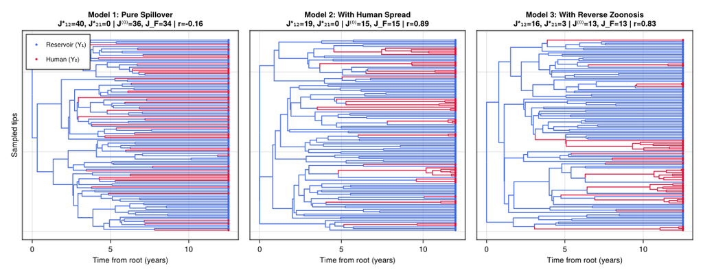

```julia
t1 = solve(make_tree_problem(model1_params(); n1 = 80, n2 = 40), CoalescentStepper(); rng = StableRNG(10))
t2 = solve(make_tree_problem(model2_params(); n1 = 80, n2 = 40), CoalescentStepper(); rng = StableRNG(20))
t3 = solve(make_tree_problem(model3_params(); n1 = 80, n2 = 40), CoalescentStepper(); rng = StableRNG(30))

fig = Figure(size = (1100, 430), fontsize = 12)
for (col, (mtitle, tr)) in enumerate([
    ("Model 1: Pure Spillover", t1),
    ("Model 2: With Human Spread", t2),
    ("Model 3: With Reverse Zoonosis", t3)
])
    bt, x, y = Phylodynamics._tree_layout_coords(tr)
    pc = parsimony_counts(bt)
    ch = cherry_assortativity(bt)
    sub = @sprintf("J*₁₂=%d, J*₂₁=%d | J⁽⁰⁾=%d, J_F=%d | r=%.2f",
        bt.true_jumps_12, bt.true_jumps_21, pc.J_pars_1to2, pc.J_pars_fitch, ch.r)
    ax = Axis(fig[1, col];
        title = "$mtitle\n$sub",
        xlabel = "Time from root (years)",
        ylabel = col == 1 ? "Sampled tips" : "",
        yticklabelsvisible = false,
        yticksvisible = false
    )
    for e in 1:size(bt.edge, 1)
        p_node = bt.edge[e, 1]
        c_node = bt.edge[e, 2]
        st_c = bt.node_state[c_node] > 0 ? bt.node_state[c_node] : (c_node <= ntips(bt) ? bt.tip_state[c_node] : 1)
        col_e = st_c == 2 ? :crimson : :royalblue
        lines!(ax, [x[p_node], x[p_node], x[c_node]], [y[p_node], y[c_node], y[c_node]]; color = col_e, linewidth = 1.3)
    end
    idx1 = findall(==(1), bt.tip_state)
    idx2 = findall(==(2), bt.tip_state)
    scatter!(ax, x[idx1], y[idx1]; color = :royalblue, markersize = 5, label = "Reservoir (Y₁)")
    scatter!(ax, x[idx2], y[idx2]; color = :crimson, markersize = 5, label = "Human (Y₂)")
    if col == 1
        axislegend(ax; position = :lt, framevisible = true, labelsize = 10)
    end
end
fig
```

## Full singleton reaction trees vs. collapsed binary trees (`ForwardBackwardSSAStepper`)

Both `simulate_forward_lineage_tree` and `simulate_forward_backward_tree` retain:

- `full_tree`: the full reaction tree containing degree-2 singleton nodes at the exact timestamps where a lineage jumps between host species (`true_jump_times_12`, `true_jump_times_21`), and
- `binary_tree`: the collapsed binary tree obtained via `collapse_singletons(full_tree)`, which is what standard phylogenetic inference observes from sequence data.

```julia
sim_m3 = simulate_forward_backward_tree(model3_params(); n1 = 50, n2 = 25, rng = StableRNG(42))
println("Full reaction tree total nodes:     ", ntotal_nodes(sim_m3.full_tree))
println("Collapsed binary tree total nodes:  ", ntotal_nodes(sim_m3.binary_tree))
println("True 1 -> 2 spillover jump times:   ", round.(sim_m3.binary_tree.true_jump_times_12, digits = 2))
println("True 2 -> 1 reverse jump times:     ", round.(sim_m3.binary_tree.true_jump_times_21, digits = 2))
```

```
Full reaction tree total nodes:     164
Collapsed binary tree total nodes:  149
True 1 -> 2 spillover jump times:   [9.46, 9.81, 10.44, 10.63, 10.76, 10.81, 10.87, 11.13, 11.82, 11.98, 12.25, 12.3, 12.57, 12.7, 12.81]
True 2 -> 1 reverse jump times:     Float64[]
```

## Lower-level `ModelFGY` / `SimTree` API and patristic distance matrices

Users can also construct `ModelFGY`, `SampleConfiguration`, and `SimTree` objects directly and compute pairwise patristic distance matrices via `distancematrix`:

[figure not shown]

```julia
mod = ModelFGY(model2_params())
scfg = SampleConfiguration([("Y1", 12.85) for _ in 1:25] ∪ [("Y2", 12.85) for _ in 1:15])
st = SimTree(mod, scfg; computedescendants = true, rng = StableRNG(99))
D = distancematrix(st)

fig_d = Figure(size = (520, 420), fontsize = 12)
ax_d = Axis(fig_d[1, 1];
    title = "Patristic Distance Matrix (1–25: Reservoir, 26–40: Human)",
    xlabel = "Tip index",
    ylabel = "Tip index",
    yreversed = true
)
hm = heatmap!(ax_d, 1:40, 1:40, D; colormap = :viridis)
Colorbar(fig_d[1, 2], hm; label = "Patristic distance (years)")
fig_d
```